# A Clinical Prediction Model for ICU Mortality

Han-Yu Hsieh

24/01/2021

# 1. Introduction

The objective is to build a prediction model for identifying patients who are likely to die during their ICU stay, and I also focus on doing some illustrative data visualization for various predictors along the way. The source of the data comes from MIMIC-III, a freely accessible critical care database - Johnson, A. E. W. et al. Sci. Data 3:160035 doi: 10.1038/sdata.2016.35 (2016). I am new to machine learning and hoping to learn more, so any feedback is very welcome.

There are three parts to my script as follows:  
- Feature engineering  
- Missing value imputation  
- Prediction

## 1.1 Load and check data

```r
knitr::opts_chunk$set(message= FALSE, echo = TRUE, cache=TRUE, warning=FALSE)
```

```r
#Load packages
library(tidyverse) # data wrangling and visualization
library(bigrquery) # connecting to BigQuery database
library(magrittr) # piping data and analysis chains
library(ggplot2) # data visualization
library(rsample) # data sampling
library(plotROC) # data visualization
library(kableExtra) # data wrangling
library(mice) # imputation
library(randomForest) # classification algorithm
```

It is also the course project for Predictive Modeling and Transforming Clinical Practice in Coursera by Dr. Laura K Wiley, and I downloaded the data from Google BigQuery.

```r
options(gargle_oauth_email = "mickey03052416@gmail.com")
con <- DBI::dbConnect(drv = bigquery(),
                      project = "learnclinicaldatascience")

admissions <- tbl(con, 'mimic3_demo.ADMISSIONS') %>%
  collect()
patients <- tbl(con, 'mimic3_demo.PATIENTS') %>%
  collect()
icustays <- tbl(con, "mimic3_demo.ICUSTAYS") %>%
  collect()
chartevents <- tbl(con, "mimic3_demo.CHARTEVENTS") %>%
  collect()
d_items <- tbl(con, "mimic3_demo.D_ITEMS") %>%
  collect()
labevents <- tbl(con, "mimic3_demo.LABEVENTS") %>%
  collect()
d_labitems <- tbl(con, "mimic3_demo.D_LABITEMS") %>%
  collect()
```

Check https://mimic.physionet.org/gettingstarted/demo/ for the detailed description for each table.

```r
str(icustays)
```

```
## tibble [136 × 12] (S3: tbl_df/tbl/data.frame)
##  $ ROW_ID        : int [1:136] 12865 12754 12824 12810 12771 12775 12825 12763 12801 12843 ...
##  $ SUBJECT_ID    : int [1:136] 10124 10017 10088 10074 10036 10040 10088 10027 10065 10106 ...
##  $ HADM_ID       : int [1:136] 170883 199207 168233 170119 189483 157839 149044 199395 183314 133283 ...
##  $ ICUSTAY_ID    : int [1:136] 295043 204881 249695 224021 227834 272047 277403 286020 245091 217960 ...
##  $ DBSOURCE      : chr [1:136] "carevue" "carevue" "carevue" "carevue" ...
##  $ FIRST_CAREUNIT: chr [1:136] "CCU" "CCU" "CCU" "MICU" ...
##  $ LAST_CAREUNIT : chr [1:136] "CCU" "CCU" "CCU" "MICU" ...
##  $ FIRST_WARDID  : int [1:136] 7 7 7 12 12 12 12 12 12 12 ...
##  $ LAST_WARDID   : int [1:136] 7 7 7 12 12 12 12 12 15 12 ...
##  $ INTIME        : POSIXct[1:136], format: "2192-04-24 02:29:49" "2149-05-29 18:52:29" ...
##  $ OUTTIME       : POSIXct[1:136], format: "2192-04-26 23:59:45" "2149-05-31 22:19:17" ...
##  $ LOS           : num [1:136] 2.896 2.144 1.623 0.655 1.807 ...
```

I know that the data set only contains 100 patients but there are 136 entries in icustays table, which means that some patients have multiple ICU stays. Let’s take a look.

```r
first_ICU_stay <- icustays %>%
  left_join(admissions, by = c("SUBJECT_ID" = "SUBJECT_ID", "HADM_ID" = "HADM_ID")) %>%
  group_by(SUBJECT_ID) %>%
  filter(INTIME == min(INTIME)) %>%
  ungroup() %>%
  select(SUBJECT_ID, HADM_ID, ICUSTAY_ID, INTIME, LOS, DIAGNOSIS, HOSPITAL_EXPIRE_FLAG)
last_ICU_stay <- icustays %>%
  left_join(admissions, by = c("SUBJECT_ID" = "SUBJECT_ID", "HADM_ID" = "HADM_ID")) %>%
  group_by(SUBJECT_ID) %>%
  filter(INTIME == max(INTIME)) %>%
  ungroup() %>%
  select(SUBJECT_ID, HADM_ID, ICUSTAY_ID, INTIME,LOS, DIAGNOSIS, HOSPITAL_EXPIRE_FLAG)

t1 <- first_ICU_stay %>% filter(HOSPITAL_EXPIRE_FLAG == 1) %>% count()
t2 <- last_ICU_stay %>% filter(HOSPITAL_EXPIRE_FLAG == 1) %>% count()
kable(list(t1, t2)) %>% kable_styling()
```

| n |
| --- |
| 33 |

| n |
| --- |
| 40 |

During the first ICU stay, 33 patients did not survive, and the number for the last ICU stay is 40. I am going to use the last ICU stay table as the data frame to do exploratory data analysis and build a prediction model.

# 2. Feature Engineering

```r
str(chartevents)
```

```
## tibble [758,355 × 15] (S3: tbl_df/tbl/data.frame)
##  $ ROW_ID      : int [1:758355] 270882580 256440445 5383123 5383121 5383124 5383122 5383120 5383125 5383126 256737084 ...
##  $ SUBJECT_ID  : int [1:758355] 40304 40304 40310 40310 40310 40310 40310 40310 40310 44212 ...
##  $ HADM_ID     : int [1:758355] 174997 174997 186361 186361 186361 186361 186361 186361 186361 163189 ...
##  $ ICUSTAY_ID  : int [1:758355] NA NA NA NA NA NA NA NA NA NA ...
##  $ ITEMID      : int [1:758355] 224101 225189 225640 225638 225641 225639 225637 225642 225643 226118 ...
##  $ CHARTTIME   : POSIXct[1:758355], format: "2163-11-24 00:00:00" "2163-11-24 00:00:00" ...
##  $ STORETIME   : POSIXct[1:758355], format: "2163-11-25 05:14:00" "2163-11-25 05:14:00" ...
##  $ CGID        : int [1:758355] 20704 20704 20889 20889 20889 20889 20889 20889 20889 20704 ...
##  $ VALUE       : chr [1:758355] "Left " "1" "1" "5" ...
##  $ VALUENUM    : num [1:758355] NA 1 1 5 37 0 0 4 44 0 ...
##  $ VALUEUOM    : chr [1:758355] NA NA "%" "%" ...
##  $ WARNING     : int [1:758355] 0 0 0 0 0 0 0 0 1 0 ...
##  $ ERROR       : int [1:758355] 0 0 0 0 0 0 0 0 0 0 ...
##  $ RESULTSTATUS: chr [1:758355] NA NA NA NA ...
##  $ STOPPED     : chr [1:758355] NA NA NA NA ...
```

```r
str(labevents)
```

```
## tibble [76,074 × 9] (S3: tbl_df/tbl/data.frame)
##  $ ROW_ID    : int [1:76074] 19951656 6300811 6246454 20168984 20448109 20168908 6283096 19952626 19951972 19955205 ...
##  $ SUBJECT_ID: int [1:76074] 40310 10126 10006 41976 44212 41976 10102 40310 40310 40310 ...
##  $ HADM_ID   : int [1:76074] 186361 160445 NA 173269 163189 NA 164869 186361 186361 186361 ...
##  $ ITEMID    : int [1:76074] 50944 51200 51200 51200 51200 51200 51200 51200 51200 51200 ...
##  $ CHARTTIME : POSIXct[1:76074], format: "2144-07-22 11:33:00" "2171-08-05 02:31:00" ...
##  $ VALUE     : chr [1:76074] "NEGATIVE" "0" "0" "0" ...
##  $ VALUENUM  : num [1:76074] NA 0 0 0 0 0 0 0 0 0 ...
##  $ VALUEUOM  : chr [1:76074] NA "%" "%" "%" ...
##  $ FLAG      : chr [1:76074] NA NA NA NA ...
```

As we can see, there are a total of 758,355 chart events and 76,074 lab events during the 136 entries in icustays table. Without any guidance, selecting the variables is no doubt like finding a needle in the haystack. Therefore, I referred to two research articles to guide me in selecting meaningful variables.  
-Reference A: https://journals.sagepub.com/doi/pdf/10.1177/1473230009037005  
-Reference B: https://healthpolicy.ucsf.edu/icu-outcomes#RESULTS

## 2.1 Diagnosis

Inspired by Reference B, I summarizes all kind of diagnosis to 5 categories - ACUTE, ACUTE CARDIAC, CANCER, CHRONIC, INFECTION, and do exploratory data analysis for diagnosis type.

```r
#Diagnosis Type
last_ICU_stay <- last_ICU_stay %>% mutate(diagnosis_type = case_when(
  grepl("(.)*CANCER|(.) CA|(.)*LEUKEMIA", DIAGNOSIS, ignore.case = TRUE) ~ "CANCER",
  grepl("(.)*SEPSIS|INFECTION|CHOLANGITIS|ABSCESS|FEVER|PNEUMONIA", DIAGNOSIS, ignore.case = TRUE) ~ "INFECTION",
  grepl("(.)*MI|VF ARREST|STROKE(.)*|CHEST PAIN|MYOCARDIAL", DIAGNOSIS, ignore.case = TRUE) ~ "ACUTE CARDIAC",
  grepl("(.)*ACCIDENT|FRACTURE|(.)*FALL|SEIZURE|BREATH|BLEED|HEMATOMA|OVERDOSE|SYNCOPE(.)*|TACHYPNEA|ACUTE",DIAGNOSIS, ignore.case = TRUE) ~ "ACUTE",
  grepl("(.)*PULMONARY|RESPIRATORY|LUNG|ASTHMA|LIVER|HEPATI(TIS|IC)|ESOPHAGEAL|OA|ARTHRITIS|(HYPO|HYPER)TENSION|HEADACHE|DISTRESS|MENTAL|HEAD|ANGINA|BRAIN|HEART FAILURE|(.)*EFFUSION|FAILURE TO THRIVE|"
        , DIAGNOSIS, ignore.case = TRUE) ~ "CHRONIC", TRUE ~ "OTHERS"))
```

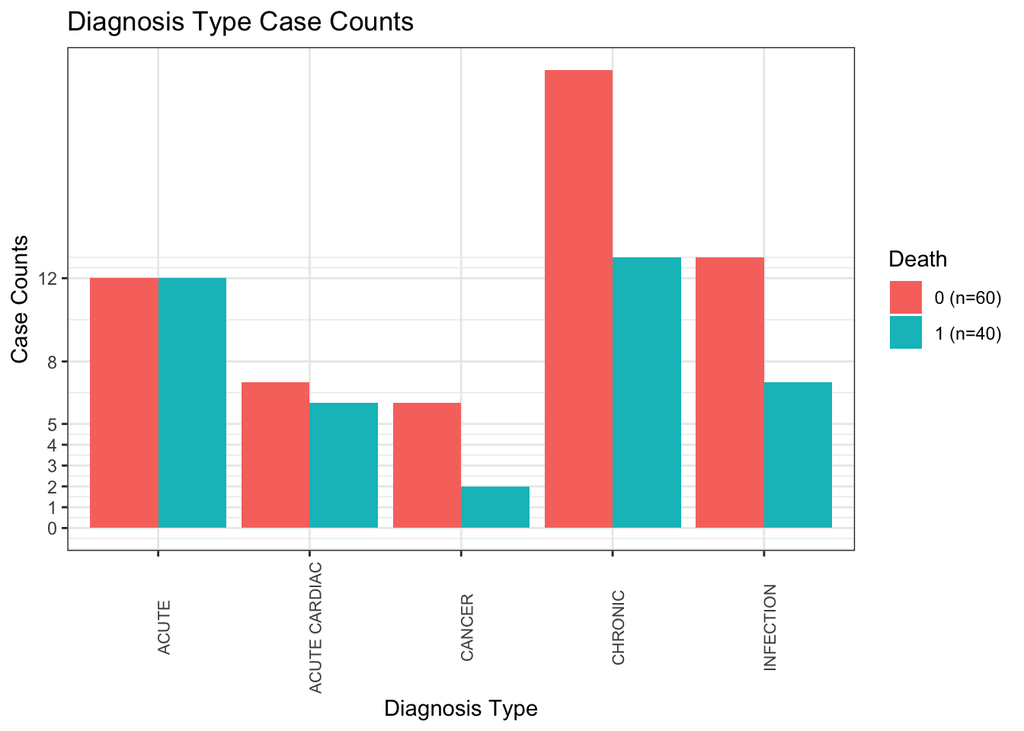

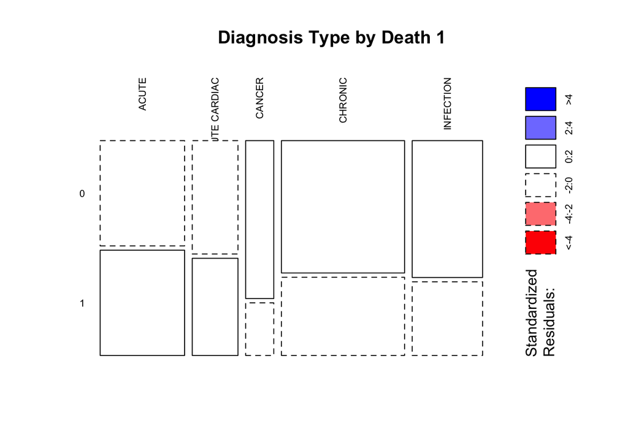

```r
ggplot(last_ICU_stay, aes(x=diagnosis_type, fill = factor(HOSPITAL_EXPIRE_FLAG)))+
  geom_bar(stat = "count", position = "dodge")+
  theme_bw()+
  theme(axis.text.x = element_text(size = 8, angle = 90))+
  labs(x= "Diagnosis Type", y="Case Counts", title = "Diagnosis Type Case Counts")+
  scale_y_continuous(breaks = c(0,1,2,3,4,5,8,12))+
  scale_fill_discrete(name="Death", labels=c("0 (n=60)","1 (n=40)"))
mosaicplot(table(last_ICU_stay$diagnosis_type, last_ICU_stay$HOSPITAL_EXPIRE_FLAG),
        main = "Diagnosis Type by Death 1", shade = TRUE, las = 2)
```

## 2.2 Ventilator Usage and Deep Stupor

From Reference B, ventilation usage and coma status have a significant impact on Intensive Care Outcomes. So I would like to make two new variables to the last_ICU_STAY table- the hours on ventilation and minimum GCS during the ICU stay from the chartevents table.

```r
#the length of ventilator usage
ventilator_label <- d_items %>%
  filter(str_detect(LABEL, pattern = regex("ventilator", ignore_case = TRUE))) %>%
  select(ITEMID)
ventilator_label <- data.matrix(sapply(ventilator_label, as.numeric))
duration_on_ventilator <- chartevents %>%
  filter(ITEMID %in% ventilator_label) %>%
  group_by(SUBJECT_ID, HADM_ID, ICUSTAY_ID) %>%
  summarise(sec_on_ventilator = max(STORETIME, na.rm = T) - min(STORETIME, na.rm = T))
last_ICU_stay <- last_ICU_stay %>%
  left_join(duration_on_ventilator)
str(last_ICU_stay)
```

```
## tibble [100 × 9] (S3: tbl_df/tbl/data.frame)
##  $ SUBJECT_ID          : int [1:100] 10017 10074 10036 10040 10088 10027 10065 10106 10043 10130 ...
##  $ HADM_ID             : int [1:100] 199207 170119 189483 157839 149044 199395 183314 133283 168674 156668 ...
##  $ ICUSTAY_ID          : int [1:100] 204881 224021 227834 272047 277403 286020 245091 217960 266122 241562 ...
##  $ INTIME              : POSIXct[1:100], format: "2149-05-29 18:52:29" "2167-02-11 22:11:30" ...
##  $ LOS                 : num [1:100] 2.144 0.655 1.807 2.131 2.009 ...
##  $ DIAGNOSIS           : chr [1:100] "HUMERAL FRACTURE" "GASTROINTESTINAL BLEED" "SEPSIS" "PULMONARY EDEMA\\CATH" ...
##  $ HOSPITAL_EXPIRE_FLAG: int [1:100] 0 0 1 0 0 0 0 0 0 0 ...
##  $ diagnosis_type      : chr [1:100] "ACUTE" "ACUTE" "INFECTION" "CHRONIC" ...
##  $ sec_on_ventilator   : 'difftime' num [1:100] NA NA 9000 63720 ...
##   ..- attr(*, "units")= chr "secs"
```

For those who has NA for sec_on_ventilator, it suggests that these patients very likely was not on a ventilator during their ICU stay. However, it is also possible that some of these patients had missing values in this variable. I am going to convert NA to 0 and treat it as no ventilator usage during the stay as well as converting seconds to hours as the unit.

```r
library(stringr)
regexp <- "[[:digit:]]+"
last_ICU_stay$sec_on_ventilator <- as.numeric(str_extract(
  last_ICU_stay$sec_on_ventilator, regexp))
last_ICU_stay <- last_ICU_stay %>%
  mutate(hr_on_ventilator = sec_on_ventilator/3600)
last_ICU_stay[is.na(last_ICU_stay$hr_on_ventilator), 10] <- 0

#Minimum GCS during the ICU stay
GSC_label <- d_items %>%
  filter(str_detect(LABEL, pattern = regex("GCS", ignore_case = TRUE))) %>%
  select(ITEMID)
GSC_label <- data.matrix(sapply(GSC_label, as.numeric))
total_GCS <- chartevents %>%
  filter(ITEMID %in% GSC_label) %>%
  group_by(SUBJECT_ID, HADM_ID, ICUSTAY_ID, CHARTTIME) %>%
  summarise(total_GCS = sum(VALUENUM))
min_GCS <- last_ICU_stay %>%
  left_join(total_GCS, by = c("SUBJECT_ID", "HADM_ID", "ICUSTAY_ID")) %>%
  select(SUBJECT_ID, HOSPITAL_EXPIRE_FLAG, total_GCS) %>%
  group_by(SUBJECT_ID) %>%
  summarise(min_GCS = min(total_GCS, na.rm = T))
last_ICU_stay <- last_ICU_stay %>%
  left_join(min_GCS)
last_ICU_stay %>% filter(is.infinite(last_ICU_stay$min_GCS))
```

| SUBJECT_ID | HADM_ID | ICUSTAY_ID | INTIME | LOS | DIAGNOSIS | HOSPITAL_EXPIRE_FLAG | diagnosis_type | sec_on_ventilator | hr_on_ventilator | min_GCS |
| --- | --- | --- | --- | --- | --- | --- | --- | --- | --- | --- |
| 10067 | 160442 | 236674 | 2130-10-06 01:35:11 | 0.1059 | S/P MOTORCYCLE ACCIDENT | 1 | ACUTE | NA | 0 | Inf |
| 10120 | 193924 | 268282 | 2115-05-12 14:53:52 | 2.6465 | LIVER FAILURE | 1 | CHRONIC | NA | 0 | Inf |
| 41976 | 153826 | 267267 | 2202-10-03 01:46:32 | 1.6397 | SEPSIS | 0 | INFECTION | NA | 0 | Inf |

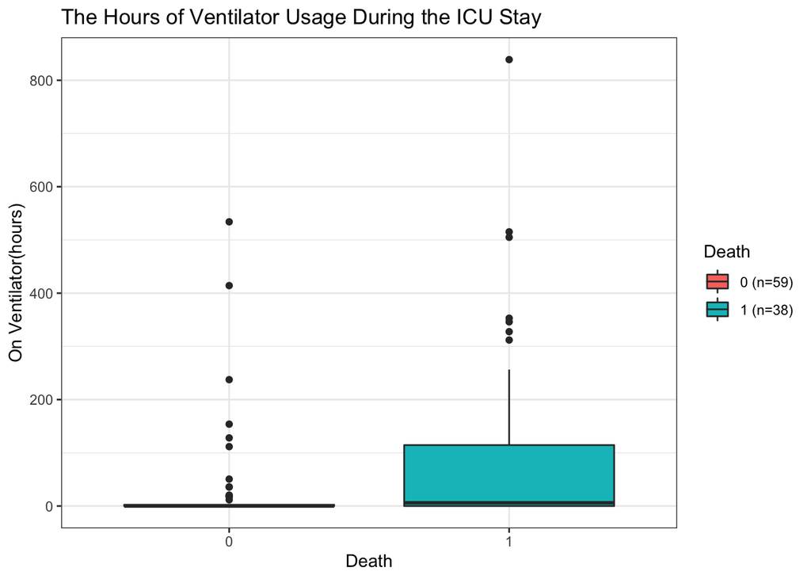

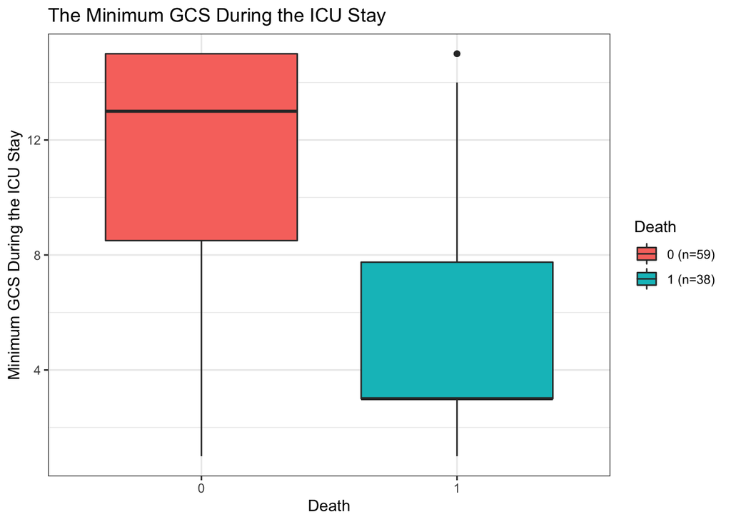

```r
#There are 3 patients, who don't have a minimum GCS and ventilator usage record. I will discuss this later.

ggplot(last_ICU_stay, aes(x= as.character(HOSPITAL_EXPIRE_FLAG),
                          y= hr_on_ventilator,
                          fill = factor(HOSPITAL_EXPIRE_FLAG)))+
  geom_boxplot(position = "dodge")+ theme_bw()+
  labs(x= "Death", y="On Ventilator(hours)",
       title = "The Hours of Ventilator Usage During the ICU Stay")+
  scale_fill_discrete(name="Death", labels=c("0 (n=59)","1 (n=38)"))

ggplot(last_ICU_stay, aes(x= as.character(HOSPITAL_EXPIRE_FLAG),
                          y= min_GCS,
                          fill = factor(HOSPITAL_EXPIRE_FLAG)))+
  geom_boxplot(position = "dodge")+ theme_bw()+
  labs(x= "Death", y="Minimum GCS During the ICU Stay",
       title = "The Minimum GCS During the ICU Stay")+
  scale_fill_discrete(name="Death", labels=c("0 (n=59)","1 (n=38)"))
```

## 2.3 Heart Rate and Blood Pressure during the ICU Stay

From Reference B, predictors like heart rate >= 150 and systolic blood pressure <= 90 have P-value < 0.001 in terms of ICU mortality. Therefore, I would like to find out the maximum heart rate and lowest blood pressure during the ICU stay from the chartevents table since I believe they are good predictors for my model building.

```r
#Maximum heart rate
d_items %>%
  filter(str_detect(LABEL, pattern =  regex("heart rate", ignore_case = TRUE))) %>%
  print()
```

```
## # A tibble: 5 x 10
##   ROW_ID ITEMID LABEL ABBREVIATION DBSOURCE LINKSTO CATEGORY UNITNAME PARAM_TYPE
##    <int>  <int> <chr> <chr>        <chr>    <chr>   <chr>    <chr>    <chr>
## 1   1078   3494 Lowe… <NA>         carevue  charte… <NA>     <NA>     <NA>
## 2    212    211 Hear… <NA>         carevue  charte… <NA>     <NA>     <NA>
## 3  12714 220047 Hear… HR Alarm - … metavis… charte… Alarms   bpm      Numeric
## 4  12713 220046 Hear… HR Alarm - … metavis… charte… Alarms   bpm      Numeric
## 5  12712 220045 Hear… HR           metavis… charte… Routine… bpm      Numeric
## # … with 1 more variable: CONCEPTID <int>
```

```r
heart_rate <- chartevents %>%
  filter(ITEMID %in% c(211, 220045)) %>%
  select(SUBJECT_ID, HADM_ID, ICUSTAY_ID, CHARTTIME, VALUENUM) %>%
  group_by(SUBJECT_ID, HADM_ID, ICUSTAY_ID) %>%
  summarise(max_heart_rate = max(VALUENUM, na.rm = TRUE))
#Lowest blood pressure
d_items %>%
  filter(str_detect(LABEL, pattern =  regex("diastolic(blood pressure)?|NBP|Arterial BP", ignore_case = TRUE))) %>%
  print()
```

```
## # A tibble: 37 x 10
##    ROW_ID ITEMID LABEL ABBREVIATION DBSOURCE LINKSTO CATEGORY UNITNAME
##     <int>  <int> <chr> <chr>        <chr>    <chr>   <chr>    <chr>
##  1   4907   8444 Orth… <NA>         carevue  charte… <NA>     <NA>
##  2    420    456 NBP … <NA>         carevue  charte… <NA>     <NA>
##  3   4953   8502 BP C… <NA>         carevue  charte… <NA>     <NA>
##  4   4827   8364 ABP … <NA>         carevue  charte… <NA>     <NA>
##  5   4831   8368 Arte… <NA>         carevue  charte… <NA>     <NA>
##  6   4908   8445 Orth… <NA>         carevue  charte… <NA>     <NA>
##  7   4326   6702 Arte… <NA>         carevue  charte… <NA>     <NA>
##  8   4325   6701 Arte… <NA>         carevue  charte… <NA>     <NA>
##  9   4956   8505 BP P… <NA>         carevue  charte… <NA>     <NA>
## 10   4957   8506 BP R… <NA>         carevue  charte… <NA>     <NA>
## # … with 27 more rows, and 2 more variables: PARAM_TYPE <chr>, CONCEPTID <int>
```

```r
blood_pressure <- chartevents %>%
  filter(ITEMID %in% c(227242, 224643, 220180, 220051,455, 8441, 5817, 8551, 8368)) %>%
  select(SUBJECT_ID, HADM_ID, ICUSTAY_ID, CHARTTIME, VALUENUM) %>%
  group_by(SUBJECT_ID, HADM_ID, ICUSTAY_ID) %>%
  summarise(min_blood_pressure = min(VALUENUM, na.rm = TRUE))
last_ICU_stay <- last_ICU_stay %>%
  left_join(heart_rate, by = c("SUBJECT_ID", "HADM_ID", "ICUSTAY_ID")) %>%
  left_join(blood_pressure, by = c("SUBJECT_ID", "HADM_ID", "ICUSTAY_ID"))
last_ICU_stay %>% filter(is.na(last_ICU_stay$max_heart_rate))
```

| SUBJECT_ID | HADM_ID | ICUSTAY_ID | INTIME | LOS | DIAGNOSIS | HOSPITAL_EXPIRE_FLAG | diagnosis_type | sec_on_ventilator | hr_on_ventilator | min_GCS | max_heart_rate | min_blood_pressure |
| --- | --- | --- | --- | --- | --- | --- | --- | --- | --- | --- | --- | --- |
| 10067 | 160442 | 236674 | 2130-10-06 01:35:11 | 0.1059 | S/P MOTORCYCLE ACCIDENT | 1 | ACUTE | NA | 0 | Inf | NA | NA |
| 10120 | 193924 | 268282 | 2115-05-12 14:53:52 | 2.6465 | LIVER FAILURE | 1 | CHRONIC | NA | 0 | Inf | NA | NA |
| 41976 | 153826 | 267267 | 2202-10-03 01:46:32 | 1.6397 | SEPSIS | 0 | INFECTION | NA | 0 | Inf | NA | NA |

Patient ID 10067,10120, 41976 not only does not have ventilator usage and GCS data but also heart rate and blood pressure data, which I will discuss later.

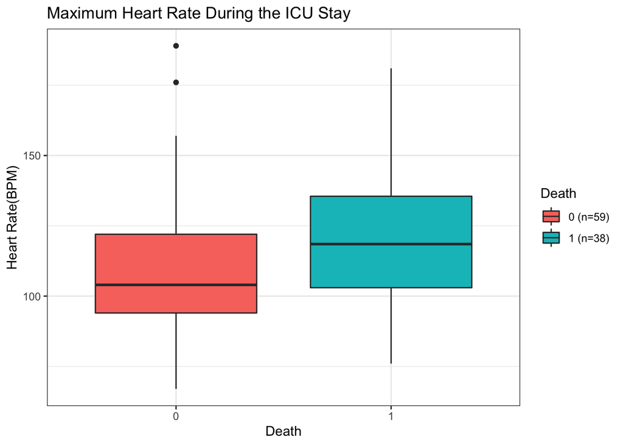

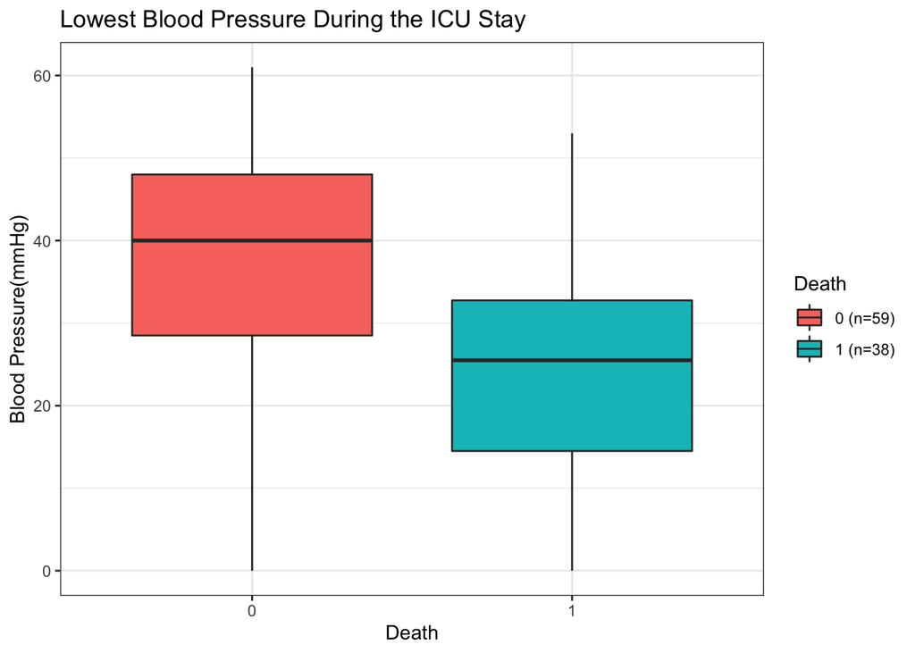

```r
ggplot(last_ICU_stay, aes(x= as.character(HOSPITAL_EXPIRE_FLAG),
                                     y= max_heart_rate,
                                     fill = factor(HOSPITAL_EXPIRE_FLAG)))+
  geom_boxplot(position = "dodge")+ theme_bw()+
  labs(x= "Death", y="Heart Rate(BPM)",
       title = "Maximum Heart Rate During the ICU Stay")+
  scale_fill_discrete(name="Death", labels=c("0 (n=59)","1 (n=38)"))

ggplot(last_ICU_stay, aes(x= as.character(HOSPITAL_EXPIRE_FLAG),
                                     y= min_blood_pressure,
                                     fill = factor(HOSPITAL_EXPIRE_FLAG)))+
  geom_boxplot(position = "dodge")+ theme_bw()+
  labs(x= "Death", y="Blood Pressure(mmHg)",
       title = "Lowest Blood Pressure During the ICU Stay")+
  scale_fill_discrete(name="Death", labels=c("0 (n=59)","1 (n=38)"))
```

## 2.4 Lowest Blood Glucose During the Hospital Admission and the Length of ICU Stay

From Reference A, it indicates BG >= 80mg/dl were relevant for survival, so I think it is g good idea to check blood glucose as a predictor. Also, inspired by Reference B, I am interested in knowing whether the length of ICU stay is relevant for survival. Let’s take a look.

```r
#Lowest Blood Glucose
d_labitems %>%
  filter(str_detect(LABEL, pattern =  regex("Glucose", ignore_case = TRUE))) %>%
  print()
```

```
## # A tibble: 10 x 6
##    ROW_ID ITEMID LABEL                FLUID                 CATEGORY  LOINC_CODE
##     <int>  <int> <chr>                <chr>                 <chr>     <chr>
##  1     10  50809 Glucose              Blood                 Blood Gas 2339-0
##  2    729  51529 Estimated Actual Gl… BLOOD                 CHEMISTRY <NA>
##  3    132  50931 Glucose              Blood                 Chemistry 2345-7
##  4    284  51084 Glucose, Urine       Urine                 Chemistry 2350-7
##  5     43  50842 Glucose, Ascites     Ascites               Chemistry 2347-3
##  6    253  51053 Glucose, Pleural     Pleural               Chemistry 2346-5
##  7    222  51022 Glucose, Joint Fluid Joint Fluid           Chemistry 2348-1
##  8    234  51034 Glucose, Body Fluid  Other Body Fluid      Chemistry 2344-0
##  9    214  51014 Glucose, CSF         Cerebrospinal Fluid … Chemistry 2342-4
## 10    678  51478 Glucose              Urine                 Hematolo… 5792-7
```

```r
min_BG<- labevents %>%
  filter(ITEMID %in% c(50809, 50931)) %>%
  group_by(SUBJECT_ID, HADM_ID) %>%
  summarise(min_BG = min(VALUENUM, na.rm = T))
last_ICU_stay <- last_ICU_stay %>%
  left_join(min_BG, by=c("SUBJECT_ID", "HADM_ID"))
#the length of ICU stay
last_ICU_stay %>% group_by(HOSPITAL_EXPIRE_FLAG) %>%
  summarise(mean=mean(LOS))
```

|  | HOSPITAL_EXPIRE_FLAG | mean |
| --- | --- | --- |
| 1 | 0 | 3.850363 |
| 2 | 1 | 6.185710 |

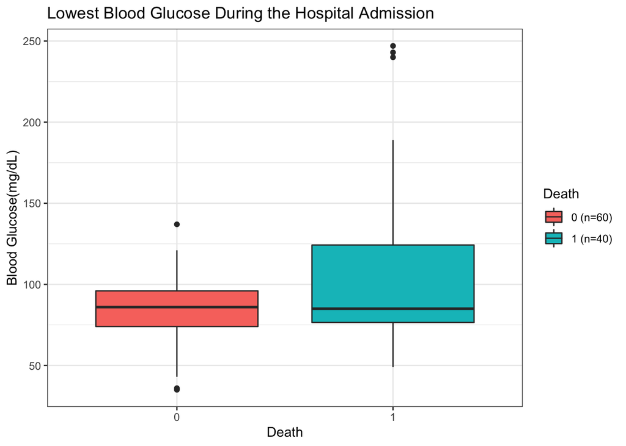

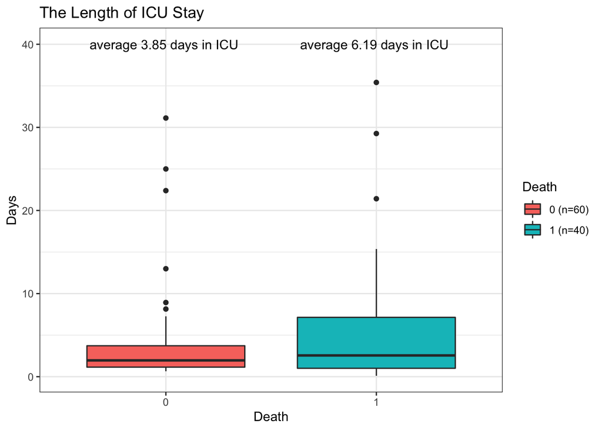

```r
ggplot(last_ICU_stay, aes(x= as.character(HOSPITAL_EXPIRE_FLAG),
                          y= min_BG,
                          fill = factor(HOSPITAL_EXPIRE_FLAG)))+
  geom_boxplot(position = "dodge")+ theme_bw()+
  labs(x= "Death", y="Blood Glucose(mg/dL)",
       title = "Lowest Blood Glucose During the Hospital Admission")+
  scale_fill_discrete(name="Death", labels=c("0 (n=60)","1 (n=40)"))
ggplot(last_ICU_stay, aes(x= as.character(HOSPITAL_EXPIRE_FLAG),
                          y= LOS,
                          fill = factor(HOSPITAL_EXPIRE_FLAG)))+
  geom_boxplot(position = "dodge")+ theme_bw()+
  labs(x= "Death", y="Days",
       title = "The Length of ICU Stay")+
  scale_fill_discrete(name="Death", labels=c("0 (n=60)","1 (n=40)"))+
  annotate("text", x=1, y=40, label="average 3.85 days in ICU ")+
  annotate("text", x=2, y=40, label="average 6.19 days in ICU ")
```

## 2.5 Gender and Age

From both references, they do not mention gender as a factor for impacting ICU outcome. As for the age variable, the coefficient with ICU mortality and the length of ICU stay is significant in Reference B. Let’s check these two variables.

```r
#Gender
gender <- patients %>%
  select(SUBJECT_ID, GENDER) %>%
  mutate(male = case_when(GENDER == "M"  ~1,
                          TRUE ~0)) %>%
  right_join(last_ICU_stay) %>%
  select(SUBJECT_ID, HADM_ID, ICUSTAY_ID, male, HOSPITAL_EXPIRE_FLAG)
#Age
date_of_birth <- patients %>%
  select(SUBJECT_ID, DOB) %>%
  right_join(last_ICU_stay) %>%
  mutate(age_intake_ICU = round(as.numeric(INTIME - DOB)/365.25))%>%
  select(SUBJECT_ID, HADM_ID, ICUSTAY_ID, age_intake_ICU, HOSPITAL_EXPIRE_FLAG)
table(is.na(date_of_birth$age_intake_ICU))
```

```
##
## FALSE  TRUE
##    92     8
```

```r
#there are 8 patients who didn't have DOB in patients table.
last_ICU_stay <- last_ICU_stay %>%
  left_join(gender) %>%
  left_join(date_of_birth)
#I am going to create a model predicting ages based on other variables.
#using mice package for this task
analysis_data <- last_ICU_stay
#Imputing Age
factor_vars <- c('LOS','diagnosis_type',"hr_on_ventilator", "min_GCS", "max_heart_rate"
                 , "min_blood_pressure", "min_BG", "male")
last_ICU_stay[factor_vars] <- lapply(last_ICU_stay[factor_vars], function(x) as.factor(x))
set.seed(20210116)
mice_mod <- mice(last_ICU_stay[, !names(last_ICU_stay) %in% c('SUBJECT_ID',
            'HADM_ID', 'ICUSTAY_ID', 'INTIME', 'HOSPITAL_EXPIRE_FLAG', 'sec_on_ventilator')], method='rf')
```

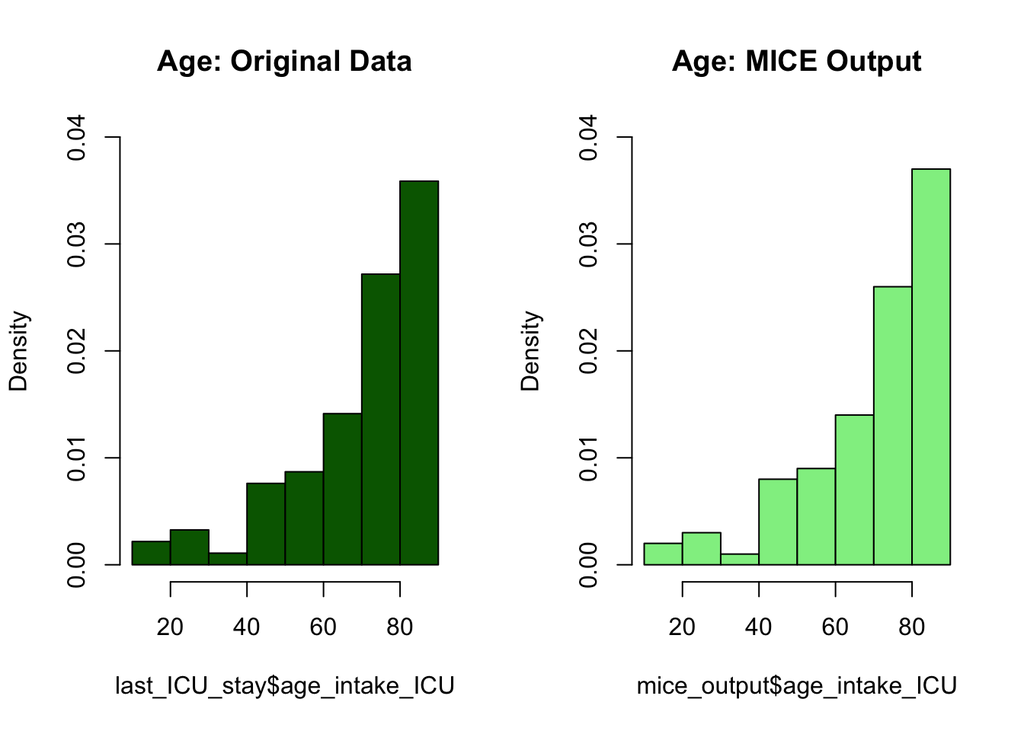

```r
mice_output <- complete(mice_mod)
#plot age distributions
par(mfrow=c(1,2))
hist(last_ICU_stay$age_intake_ICU, freq = F, main = "Age: Original Data",
     col = 'darkgreen', ylim = c(0, 0.04))
hist(mice_output$age_intake_ICU, freq = F, main = "Age: MICE Output",
     col = 'lightgreen', ylim = c(0, 0.04))
```

```r
#The imputing looks good, and I am going to replace the age vector in the original data.
analysis_data$age_intake_ICU <- mice_output$age_intake_ICU
```

## 3. Missingness

```r
analysis_data %>% filter(is.na(analysis_data$max_heart_rate))
```

| SUBJECT_ID | HADM_ID | ICUSTAY_ID | INTIME | LOS | DIAGNOSIS | HOSPITAL_EXPIRE_FLAG | diagnosis_type | sec_on_ventilator | hr_on_ventilator | min_GCS | max_heart_rate | min_blood_pressure | min_BG | male | age_intake_ICU |
| --- | --- | --- | --- | --- | --- | --- | --- | --- | --- | --- | --- | --- | --- | --- | --- |
| 10067 | 160442 | 236674 | 2130-10-06 01:35:11 | 0.1059 | S/P MOTORCYCLE ACCIDENT | 1 | ACUTE | NA | 0 | Inf | NA | NA | 102 | 1 | 29 |
| 10120 | 193924 | 268282 | 2115-05-12 14:53:52 | 2.6465 | LIVER FAILURE | 1 | CHRONIC | NA | 0 | Inf | NA | NA | 75 | 1 | 27 |
| 41976 | 153826 | 267267 | 2202-10-03 01:46:32 | 1.6397 | SEPSIS | 0 | INFECTION | NA | 0 | Inf | NA | NA | 89 | 1 | 66 |

Patient 10067,10120, 41976 does not have ventilator usage, GCS, heart rate, blood pressure record. Due to the lack of many variables, I decide to delete these 3 patients entirely and use the 97 entries as analytic data to build a prediction model.

```r
analysis_data <- analysis_data[!is.na(analysis_data$max_heart_rate), ]
analysis_data
```

| SUBJECT_ID | HADM_ID | ICUSTAY_ID | INTIME | LOS | DIAGNOSIS | HOSPITAL_EXPIRE_FLAG | diagnosis_type | sec_on_ventilator | hr_on_ventilator | min_GCS | max_heart_rate | min_blood_pressure | min_BG | male | age_intake_ICU |
| --- | --- | --- | --- | --- | --- | --- | --- | --- | --- | --- | --- | --- | --- | --- | --- |
| 10017 | 199207 | 204881 | 2149-05-29 18:52:29 | 2.1436 | HUMERAL FRACTURE | 0 | ACUTE | NA | 0.00000000 | 13 | 104 | 33 | 137 | 0 | 74 |
| 10074 | 170119 | 224021 | 2167-02-11 22:11:30 | 0.6549 | GASTROINTESTINAL BLEED | 0 | ACUTE | NA | 0.00000000 | 15 | 131 | 49 | 105 | 1 | 85 |
| 10036 | 189483 | 227834 | 2185-03-24 16:57:05 | 1.8068 | SEPSIS | 1 | INFECTION | 9000 | 2.50000000 | 7 | 102 | 20 | 55 | 0 | 73 |
| 10040 | 157839 | 272047 | 2147-02-23 11:43:47 | 2.1306 | PULMONARY EDEMA\\CATH | 0 | CHRONIC | 63720 | 17.70000000 | 3 | 109 | 28 | 86 | 0 | 85 |
| 10088 | 149044 | 277403 | 2107-05-12 18:00:52 | 2.0091 | UROSEPSIS | 0 | INFECTION | NA | 0.00000000 | 11 | 125 | 20 | 100 | 1 | 78 |
| 10027 | 199395 | 286020 | 2190-07-13 10:39:07 | 7.2616 | MITRAL REGURGITATION;CORONARY ARTERY DISEASE\\CORONARY ARTERY BYPASS GRAFT WITH MVR ? MITRAL VALVE REPLACEMENT /SDA | 0 | ACUTE CARDIAC | 460980 | 128.05000000 | 3 | 176 | 11 | 58 | 0 | 82 |
| 10065 | 183314 | 245091 | 2189-09-08 10:00:31 | 2.2559 | ESOPHAGEAL CANCER/SDA | 0 | CANCER | 63960 | 17.76666667 | 3 | 95 | 27 | 96 | 0 | 78 |
| 10106 | 133283 | 217960 | 2161-09-15 03:04:48 | 1.9231 | HEADACHE | 0 | CHRONIC | NA | 0.00000000 | 14 | 108 | 31 | 93 | 1 | 64 |
| 10043 | 168674 | 266122 | 2185-04-14 00:23:56 | 2.0141 | RESPIRATORY DISTRESS | 0 | CHRONIC | 128880 | 35.80000000 | 10 | 117 | 49 | 79 | 1 | 76 |
| 10130 | 156668 | 241562 | 2161-02-04 21:06:00 | 1.6444 | ABSCESS | 0 | INFECTION | NA | 0.00000000 | 15 | 125 | 51 | 60 | 1 | 52 |

[output cut: 87 more lines]

## 4. Prediction

At last, I’m ready to build a prediction model to identify who survives during the ICU stay based on variables that I carefully curated and treated for missing values. For this, I will rely on the Binomial Regression Model and RandomForest classification algorithm. Then I will evaluate the two prediction models.  
## 4.1 Regression Model

```r
set.seed(2021)
data_split <- initial_split(analysis_data, prop = 7/10)
training_data <- training(data_split)
testing_data <- testing(data_split)
model_bin <- training_data %>%
  glm(formula = HOSPITAL_EXPIRE_FLAG ~ LOS+diagnosis_type+hr_on_ventilator+min_GCS
      +max_heart_rate+min_blood_pressure+min_BG+male+age_intake_ICU,
      family = 'binomial')
summary(model_bin)
```

```
##
## Call:
## glm(formula = HOSPITAL_EXPIRE_FLAG ~ LOS + diagnosis_type + hr_on_ventilator +
##     min_GCS + max_heart_rate + min_blood_pressure + min_BG +
##     male + age_intake_ICU, family = "binomial", data = .)
##
## Deviance Residuals:
##     Min       1Q   Median       3Q      Max
## -1.7228  -0.4875  -0.2159   0.1436   2.4493
##
## Coefficients:
##                             Estimate Std. Error z value Pr(>|z|)
## (Intercept)                 -8.03761    5.98910  -1.342   0.1796
## LOS                         -0.45346    0.25422  -1.784   0.0745 .
## diagnosis_typeACUTE CARDIAC  2.63858    2.18863   1.206   0.2280
## diagnosis_typeCANCER         1.16871    1.82151   0.642   0.5211
## diagnosis_typeCHRONIC        1.26519    1.33622   0.947   0.3437
## diagnosis_typeINFECTION      3.55360    1.84049   1.931   0.0535 .
## hr_on_ventilator             0.02876    0.01274   2.258   0.0239 *
## min_GCS                     -0.19317    0.10114  -1.910   0.0561 .
## max_heart_rate               0.01110    0.02225   0.499   0.6180
## min_blood_pressure          -0.06271    0.02796  -2.243   0.0249 *
## min_BG                       0.06032    0.02938   2.053   0.0401 *
## male                         3.76766    1.51102   2.493   0.0127 *
## age_intake_ICU               0.01797    0.03611   0.498   0.6187
## ---
## Signif. codes:  0 '***' 0.001 '**' 0.01 '*' 0.05 '.' 0.1 ' ' 1
##
## (Dispersion parameter for binomial family taken to be 1)
##
##     Null deviance: 89.446  on 67  degrees of freedom
## Residual deviance: 40.448  on 55  degrees of freedom
## AIC: 66.448
##
## Number of Fisher Scoring iterations: 7
```

```r
training_data$predicted_outcome <- predict(model_bin, training_data,
                                           type = "response")
training_roc <- training_data %>%
  ggplot(aes(m= predicted_outcome, d=HOSPITAL_EXPIRE_FLAG))+
  labs(title = "ROC Plot for Training Data")+
  geom_roc(n.cuts = 10, labels = F, labelround = 4)+
  style_roc(theme = theme_grey)
calc_auc(training_roc)$AUC*100
```

```
## [1] 93.02326
```

The Binomial model has an AUC of 93.02% in training data, which is surprisingly good, and I hope the AUC in testing data will stay the same.

```r
#Quantitative Validation
testing_data$predicted_outcome <- predict(model_bin, testing_data,
                                        type = "response")
testing_roc <- testing_data %>%
  ggplot(aes(m= predicted_outcome, d= HOSPITAL_EXPIRE_FLAG))+
  labs(title = "ROC Plot for Testing Data")+
  geom_roc(n.cuts = 10, labels = F, labelround = 4) +
  style_roc(theme = theme_grey)
calc_auc(testing_roc)$AUC*100
```

```
## [1] 68.26923
```

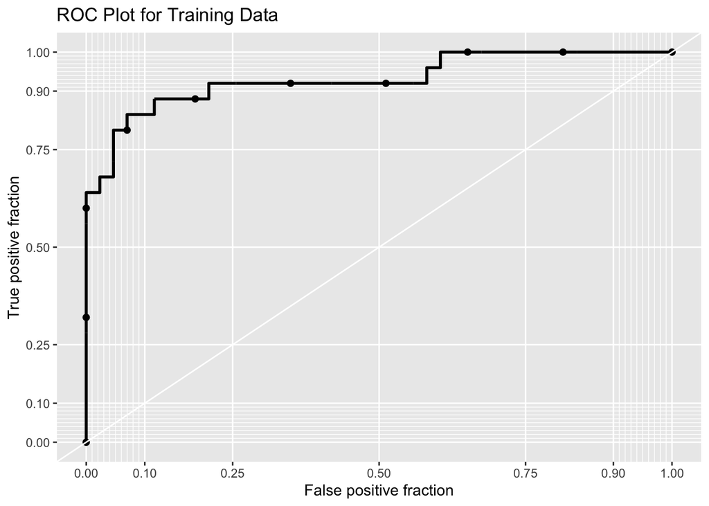

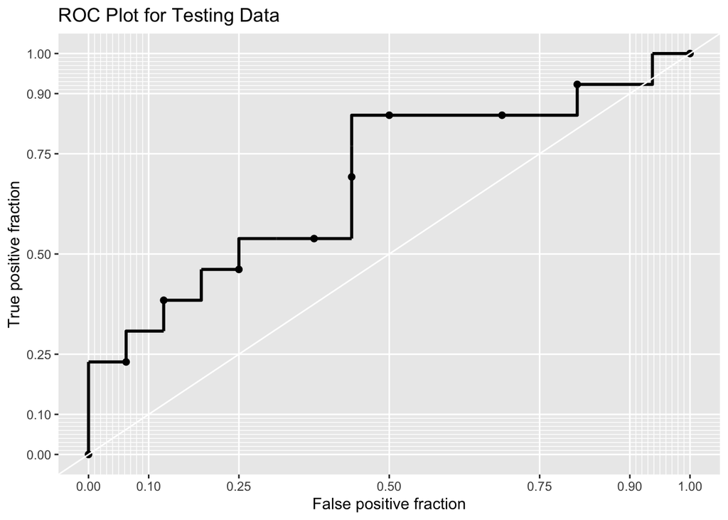

```r
training_roc
testing_roc
```

As we can see, the performance of this model got significantly worse in the testing_data. An AUC of 68.3% is quite poor - because an AUC of 50% means the model is unable to distinguish between the two outcomes. Therefore, the Binomial Model is not ideal. Let’s move on to RandomForest classification model building.

## 4.2 RandomForest

```r
set.seed(20210117)
model_rf <- randomForest(factor(HOSPITAL_EXPIRE_FLAG) ~ LOS+diagnosis_type
                         +hr_on_ventilator+min_GCS+max_heart_rate
                         +min_blood_pressure+min_BG+male+age_intake_ICU,
                          data = analysis_data, na.action = na.exclude)
print(model_rf)
```

```
##
## Call:
##  randomForest(formula = factor(HOSPITAL_EXPIRE_FLAG) ~ LOS + diagnosis_type +      hr_on_ventilator + min_GCS + max_heart_rate + min_blood_pressure +      min_BG + male + age_intake_ICU, data = analysis_data, na.action = na.exclude)
##                Type of random forest: classification
##                      Number of trees: 500
## No. of variables tried at each split: 3
##
##         OOB estimate of  error rate: 21.65%
## Confusion matrix:
##    0  1 class.error
## 0 50  9   0.1525424
## 1 12 26   0.3157895
```

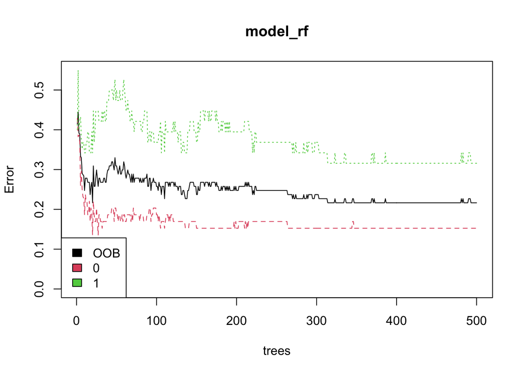

```r
#The model error
par(mfrow=c(1,1))
plot(model_rf, ylim=c(0,0.55))
legend("bottomleft", colnames(model_rf$err.rate), col = 1:3, fill = 1:3)
```

The black line shows the overall out-of-bag error rate which falls around 21.6%. The red and green lines show the error rate for ‘survived’ and ‘died’ respectively. We can see that right now I’m much more successful in predicting survival than death. I believe it is strongly related to the variable selection. Let’s look at relative variable importance by plotting the mean decrease in Gini calculated across all trees.

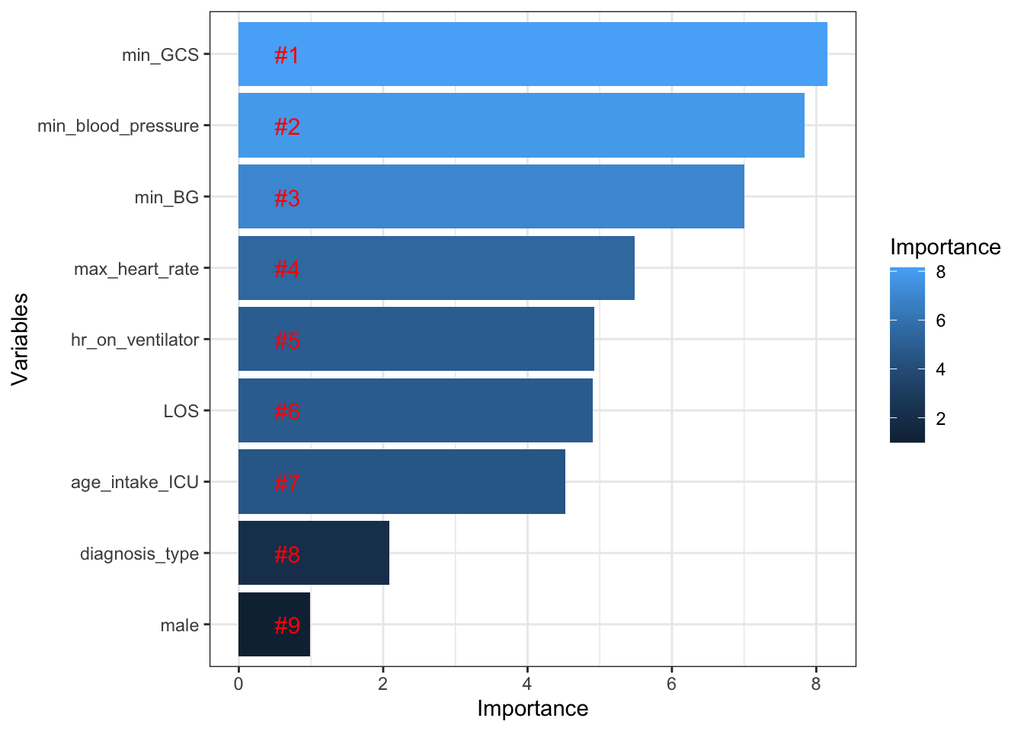

```r
#Variable importance
importance <- importance(model_rf)
varImprtance <- data.frame(variables = row.names(importance),
                           Importance = round(importance[, 'MeanDecreaseGini'], 2))
rankImportance <- varImprtance %>%
  mutate(Rank = paste0('#', dense_rank(desc(Importance))))

ggplot(rankImportance, aes(x= reorder(variables, Importance),
                           y = Importance, fill= Importance))+
  geom_bar(stat = 'identity') +
  geom_text(aes(x= variables, y=0.5, label = Rank),
            hjust=0, vjust=0.55, size=4, color='red')+
  labs(x='Variables')+
  coord_flip()+
  theme_bw()
```

The minimum GCS, the minimum blood pressure and the minimum blood glucose are the top three highest relative importance out of all the predictor variables. I am not surprised to see the gender is the least relevant variable since both references do not indicate it as an important variable.

## 5. Conclusion

By referencing two ICU outcome retrospective studies, I identified 9 variables from 758 thousands of chat events and 76 thousands of lab events and built a RamdomForest Model to predict who survives during the ICU stay with a 21.6% OOB error rate. As a beginner in Machine Learning, I am happy with the algorithm and look forward to doing more.